# Activity Monitoring Data

### Loading the Data

```r
## read the csv file
activity <- read.csv("activity.csv")
summary(activity)
```

```
##      steps                date          interval
##  Min.   :  0.00   2012-10-01:  288   Min.   :   0.0
##  1st Qu.:  0.00   2012-10-02:  288   1st Qu.: 588.8
##  Median :  0.00   2012-10-03:  288   Median :1177.5
##  Mean   : 37.38   2012-10-04:  288   Mean   :1177.5
##  3rd Qu.: 12.00   2012-10-05:  288   3rd Qu.:1766.2
##  Max.   :806.00   2012-10-06:  288   Max.   :2355.0
##  NA's   :2304     (Other)   :15840
```

### Steps per day

To plot the total number of steps in any day, we use hist function after we split the data on the date and add the steps in each split.

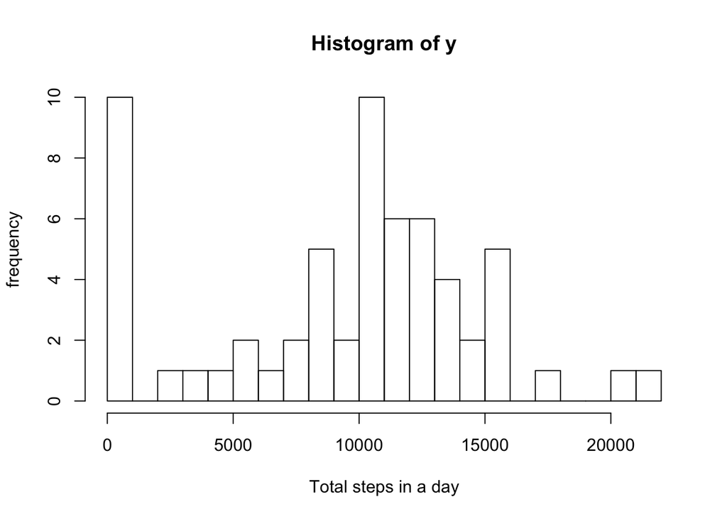

```r
##split the data based on the date
s <- split(activity, activity$date)
## and then sum over the number of steps in that date
y <-sapply(s, function(x) sum(x[,"steps"], na.rm=TRUE))

##given that dates is a factor variable, I am using the levels function to get all the unique values as opposed to unique
dates <-levels(activity$date)

## and  adataframe of dates and the number of steps
df<- data.frame(dates,y)

## histogram plot
hist(y, breaks = 20, xlab="Total steps in a day", ylab="frequency")
```

To calculate, mean and median of the steps in each day, we use the following code:

```r
## one can also use (mean(df[,2]), median(df[,2]))
mean1 <- as.integer(mean(df[,2]))
median1 <- median(df[,2])
summary(df[,2])
```

```
##    Min. 1st Qu.  Median    Mean 3rd Qu.    Max.
##       0    6778   10395    9354   12811   21194
```

showing that median(number_steps) = 10395 and mean(number_steps)= 9354.

To show the time-series graph, we need to get the data split on the time interval and make a new data.frame called dftime.

### Average daily activity pattern

We now split on the interval

```r
stime <- split(activity,activity$interval)
ytime <- sapply(stime, function(x) mean(x[,"steps"], na.rm=TRUE))
intervals <- unique(activity$interval)
dftime<-data.frame(intervals,ytime)
```

We then use dftime for finding the interval with the maximum average steps, and we will also get the summary on the time series vector we just made:

```r
index <- which(dftime$ytime == max(dftime$ytime,na.rm=T),arr.ind = T)
dftime[index,1]
```

```
## [1] 835
```

```r
summary(dftime$ytime)
```

```
##    Min. 1st Qu.  Median    Mean 3rd Qu.    Max.
##   0.000   2.486  34.113  37.383  52.835 206.170
```

Now we plot the time series

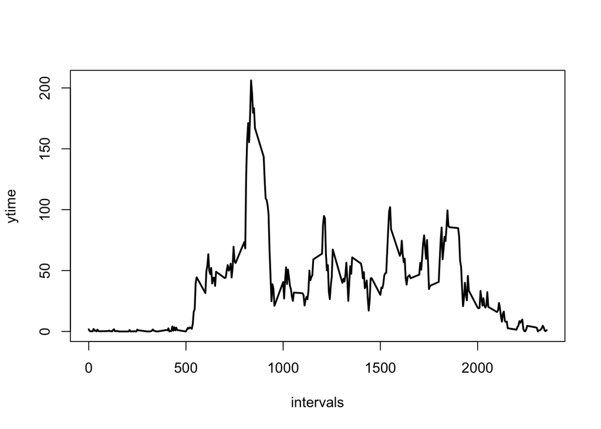

```r
plot(intervals,ytime,type ="l",lwd=2)
```

### Imputing Missing values

For calculating the missing values entries, we start with counting them

```r
OK <- sum(is.na(activity))
OK
```

```
## [1] 2304
```

Now to impute the NA values, I am going to use the mean for that 5 minute interval

```r
activity2<- activity
activity2$steps <- with(activity2, ave(steps, intervals,
   FUN = function(x) replace(x, is.na(x), as.integer(mean(x, na.rm = TRUE)))))
head(activity2)
```

```
##   steps       date interval
## 1     1 2012-10-01        0
## 2     0 2012-10-01        5
## 3     0 2012-10-01       10
## 4     0 2012-10-01       15
## 5     0 2012-10-01       20
## 6     2 2012-10-01       25
```

The new histogram plot

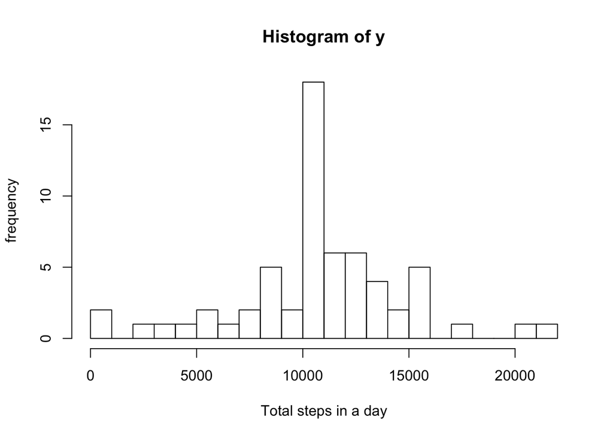

```r
##split the data based on the date
s <- split(activity2, activity$date)
## and then sum over the number of steps in that date
y <-sapply(s, function(x) sum(x[,"steps"]))

##given that dates is a factor variable, I am using the levels function to get all the unique values as opposed to unique
dates <-levels(activity2$date)

## and  adataframe of dates and the number of steps
df2<- data.frame(dates,y)

## histogram plot
hist(y, breaks = 20, xlab="Total steps in a day", ylab="frequency")
```

```r
newmedian <- median(y)
newmean <- as.integer(mean(y))
```

Showing that now the new mean 10749 and the new median is 10641, which are different than the values calculated earlier. The impact of this particular method is

```r
meanimpact <- (newmean -mean1)/mean1 *100
medianimpact <- (newmedian-median1)/median1 *100
```

showing that the impact of my method of imputation on the mean calculation is 14.913406% and on the median calculation is 2.3665224%.

### Difference between weekdays and weekends

To find the activity level variation between weekdays and weekends, we add a column of weekday/weekend values to the new data frame (activity2).

```r
activity2$dayend <- "placeholder"
#Note that date is a factor level so I changed it to class Date to use the weekdays function on it
activity2$dayend <- ifelse (weekdays(as.Date(activity2$date)) %in% c("Saturday","Sunday"), "Weekend","Weekday")
activity2$dayend <- as.factor(activity2$dayend)
head(activity2)
```

```
##   steps       date interval  dayend
## 1     1 2012-10-01        0 Weekday
## 2     0 2012-10-01        5 Weekday
## 3     0 2012-10-01       10 Weekday
## 4     0 2012-10-01       15 Weekday
## 5     0 2012-10-01       20 Weekday
## 6     2 2012-10-01       25 Weekday
```

And we now plot them

```r
## split based on two columns
activityend <- activity2[ which(activity2$dayend =="Weekend"), ]
send <- split(activityend,activityend$interval)
yend <- sapply(send, function(x) mean(x[,"steps"]))
yend
```

[output not shown]

[output cut: 17 more lines]

[output not shown]

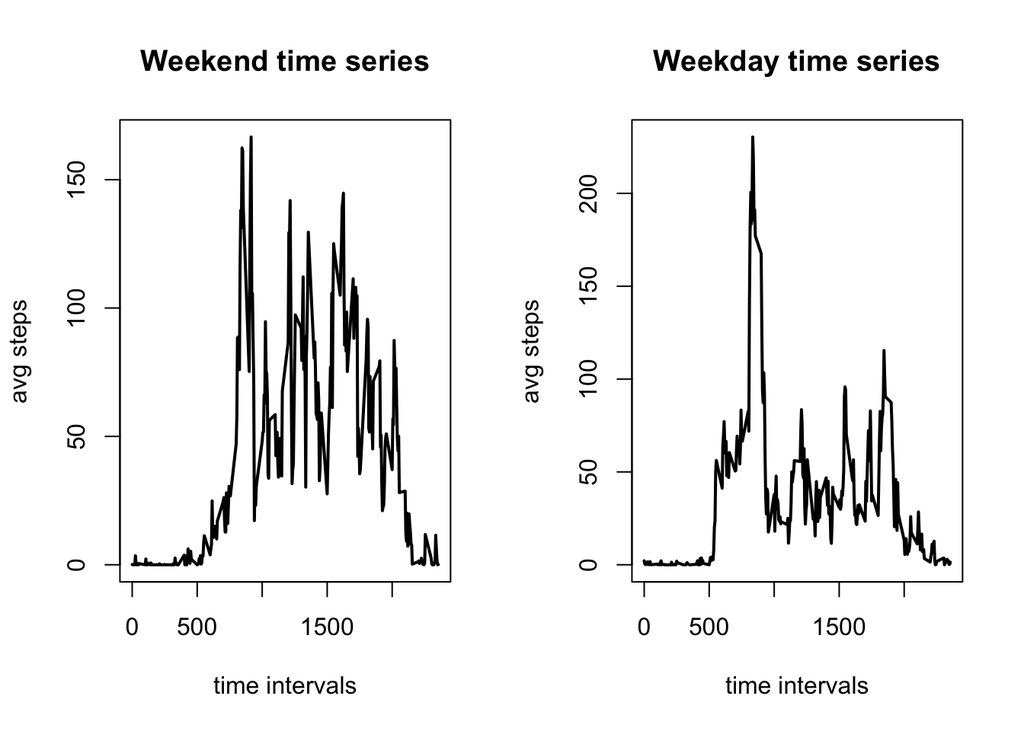

```r
activityday <- activity2[ which(activity2$dayend =="Weekday"), ]
sday <- split(activityday,activityday$interval)
yday <- sapply(sday, function(x) mean(x[,"steps"]))

##plotting
par(mfrow=c(1,2))
plot(intervals, yend, main="Weekend time series",type="l",lwd=2, xlab="time intervals", ylab="avg steps")
plot(intervals,yday, main="Weekday time series",type ="l",lwd=2, xlab="time intervals", ylab="avg steps")
```

It seems the patterns are quite different. While in weekdays, the biggest peak is at the morning commute time, on the weekends the pattern is more widespread, with many peaks throughout the waking hours. Both sets have the lowest values at the midnigh-5:00 AM period (000-500 intervals).